# Voorbereiding Onderzoekstechnieken

Jules Vervaeke

```r
wiskunde_data <- read_csv(file ="npe-1920-wiskundige-geletterdheid.csv")
muziekwijn <- read_csv(file="MuziekWijn.csv", col_types = cols(Muziek = col_factor(levels = c("Geen", "Franse", "Italiaanse")),
                                                               Wijn = col_factor(levels = c("Franse", "Italiaanse", "Andere"))))
passagiers2 <- read_csv(file="Passagiers2.csv") %>%
  mutate(time = parse_date(time, format = "%b-%Y"))
```

summary() op één rij of een volledige dataset: Een samenvatting tonen (minimum, maximum, kwartielen, mediaan en gemiddelde) IQR() op één rij: Interkwartielafstand berekenen var() op één rij: variantie sd() op één rij: standaarddeviatie length(): aantal waarnemingen in een rij

levels(): toont alle mogelijke opties unique(): zie hierboven table(): toont de frequentie van alle opties

```r
summary(cars)
```

```
##      speed           dist
##  Min.   : 4.0   Min.   :  2.00
##  1st Qu.:12.0   1st Qu.: 26.00
##  Median :15.0   Median : 36.00
##  Mean   :15.4   Mean   : 42.98
##  3rd Qu.:19.0   3rd Qu.: 56.00
##  Max.   :25.0   Max.   :120.00
```

```r
summary(cars$speed)
```

```
##    Min. 1st Qu.  Median    Mean 3rd Qu.    Max.
##     4.0    12.0    15.0    15.4    19.0    25.0
```

```r
IQR(cars$speed)
```

```
## [1] 7
```

```r
sd(cars$speed)
```

```
## [1] 5.287644
```

```r
variance <- sum((cars$speed - mean(cars$speed))^2)/(length(cars$speed)-1)
variance
```

```
## [1] 27.95918
```

```r
var(cars$speed)
```

```
## [1] 27.95918
```

```r
levels(esoph$agegp)
```

```
## [1] "25-34" "35-44" "45-54" "55-64" "65-74" "75+"
```

```r
unique(esoph$agegp)
```

```
## [1] 25-34 35-44 45-54 55-64 65-74 75+
## Levels: 25-34 < 35-44 < 45-54 < 55-64 < 65-74 < 75+
```

```r
table(esoph$agegp)
```

```
##
## 25-34 35-44 45-54 55-64 65-74   75+
##    15    15    16    16    15    11
```

## Kansen berekenen

Je kan werken met de z-score (gebaseerd op het gemiddelde en de standaardafwijking) of met de waarneming, het gemiddelde en de standaardafwijking zelf. De formules met pnorm/qnorm gelden enkel voor normale verdelingen met meer dan 30 proefpersonen

Linkerstaartkans berekent de kans dat jouw waarneming of kleiner gevonden wordt binnen de verdeling: pnorm Rechterstaartkans berekent de kans de jouw waarneming of groter gevonden wordt binnen de verdeling: 1-pnorm

Het significantieniveau bepaalt de kans op een fout van Type I als we veronderstellen dat de nulhypothese waar is. M.a.w. dit is de kans, als H0 waar is, dat we toch een steekproef nemen met zulke extreme waarden dat het steekproefgemiddelde toch in het kritieke gebied zou liggen.

```r
gemiddelde <- 5
standaardafwijking <- 1.5
waarneming <- 6.5

z <- (waarneming-gemiddelde)/standaardafwijking
pnorm(z)
```

```
## [1] 0.8413447
```

```r
pnorm(waarneming, gemiddelde, standaardafwijking)
```

```
## [1] 0.8413447
```

```r
1-pnorm(z)
```

```
## [1] 0.1586553
```

Als je een gegeven percentage krijgt, dan kan je de bijhorende waarde berekenen met qnorm

```r
gemiddelde <- 5
standaardafwijking <- 1.5
percentage <- 0.65

qnorm(percentage, gemiddelde, standaardafwijking)
```

```
## [1] 5.577981
```

Hieronder zie je het gemiddelde en de standaardafwijking van de populatie en het aantal proefpersonen binnen een nieuwe steekproef. Bepaal de kans dat $\overline{x}$ kleiner is dan 185, tussen 175 en 185 ligt en groter is dan 190 Let op: Vanaf hier delen we de standaarddeviatie door de vierkantswortel van het aantal waarnemingen. Dit is omdat we een normaalverdeling volgen met mean = gemiddelde en sd s/sqrt(n).

```r
m <- 183
s <- 36
n <- 81

pnorm(185, mean = m, sd = s / sqrt(n))
```

```
## [1] 0.6914625
```

```r
pnorm(185, mean = m, sd = s / sqrt(n)) - pnorm(175, mean = m, sd = s / sqrt(n))
```

```
## [1] 0.6687123
```

```r
1 - pnorm(190, mean = m, sd = s / sqrt(n))
```

```
## [1] 0.04005916
```

## Betrouwbaarheidsinterval

Hoe meer waarnemingen, hoe smaller uw betrouwbaarheidsinterval. Als je minder dan 30 personen hebt, gebruik qt ipv qnorm. Hoe zekerder je wilt zijn, hoe breder uw interval => 99% heeft een breder betrouwbaarheidsinterval dan 95%; 100% is infinity

```r
# Stap 1
m <- 5.2      # steekproefgemiddelde
s <- 1.5      # standaardafwijking van de populatie
n <- 100     # steekproefgrootte
alpha <- 0.05 # 1 - alpha is het zekerheidsniveau
# Stap 2
z <- qnorm(1-alpha/2) #Delen door 2 omdat je een tweezijdig interval hebt
z
```

```
## [1] 1.959964
```

```r
# Stap 3: het betrouwbaarheidsinterval
low  <- m - z * s / sqrt(n)
high <- m + z * s / sqrt(n)
c(low, high)
```

```
## [1] 4.906005 5.493995
```

## Z-toets

```r
n <- 30
sm <- 3.483
s <- 0.55
a <- 0.05
m0 <- 3.3

# Methode 1 . Overschrijdingskans
p <- 1 - pnorm(sm, m0, s/sqrt(n)) # => 0.03419546
p
```

```
## [1] 0.03419546
```

```r
#Methode 2. Kritieke grensgebied
# Onder welke waarde kan je H0 niet verwerpen ?
g <- m0 + qnorm(1-a )*s/sqrt(n)
g
```

```
## [1] 3.465169
```

## T-toets (bij steekproef kleiner dan 30)

```r
n <- 25
sm <- 3.483
ss <- 0.55
a <- 0.05
m0 <- 3.3

# Methode 1 . Overschrijdingskans
p <- 1-pt((sm-m0)/(ss/sqrt(n)), df=n-1)
p
```

```
## [1] 0.0545951
```

```r
#OF
#t.test(NaamRij, mu = 3.3,alternative = "greater",conf.level = 1 - a, df = n-1)

#Methode 2. Kritieke grensgebied
# Onder welke waarde kan je H0 niet verwerpen ?
g <- m0 + qt(1-a ,df=n-1)*ss/sqrt(n)
g
```

```
## [1] 3.488197
```

## Kwalitatief-kwalitatief

Als je een kruistabel maakt, zet dan de afhankelijke variabele eerst en de onafhankelijke variabele 2de. Bij verbanden tussen kwalitatieve variabelen gebruik je altijd de chi kwadraat test. Kramer's V duidt op de sterkte: V = 0 geen samenhang V ≈ 0,1 zwakke samenhang V ≈ 0,25 redelijk sterke samenhang V ≈ 0,50 sterke samenhang V ≈ 0,75 zeer sterke samenhang V = 1 volledige samenhang

```r
#Kruistabel opzetten
observed <- table(muziekwijn$Wijn, muziekwijn$Muziek)
observed
```

```
##
##              Geen Franse Italiaanse
##   Franse       30     39         30
##   Italiaanse   11      1         19
##   Andere       43     35         35
```

```r
#addmargins(observed)

#Chi-squared test
model <- chisq.test(observed)
model
```

```
##
##  Pearson's Chi-squared test
##
## data:  observed
## X-squared = 18.279, df = 4, p-value = 0.001088
```

```r
#Verwachte waardes (handig om de regel van Cochran te testen (alle waardes moeten minstens 1 zijn, 80% van de waardes moeten minstens 5 zijn ))
model$expected
```

```
##
##                  Geen    Franse Italiaanse
##   Franse     34.22222 30.555556   34.22222
##   Italiaanse 10.71605  9.567901   10.71605
##   Andere     39.06173 34.876543   39.06173
```

```r
#P-waarde
model$p.value
```

```
## [1] 0.00108828
```

```r
#Gestandaardiseerde residuen bekijken
model$stdres
```

```
##
##                     Geen      Franse  Italiaanse
##   Franse     -1.15908010  2.38669200 -1.15908010
##   Italiaanse  0.11480617 -3.56656228  3.34934534
##   Andere      1.06504013  0.03437385 -1.09842697
```

```r
#Cramer's V ()
observed_stats <- assocstats(observed)
observed_stats$cramer
```

```
## [1] 0.193937
```

De chi kwadraat test kan ook gebruikt worden om een goodness of fit test uit te voeren.

```r
types      <- c("mutant", "human", "alien", "god", "demon")
observed   <- c(   127,      75,      98,     27,     73)
expected_p <- c(   .35,     .17,     .23,    .08,    .17)

chisq_test_result <- chisq.test(observed, p = expected_p)
chisq_test_result
```

```
##
##  Chi-squared test for given probabilities
##
## data:  observed
## X-squared = 3.4679, df = 4, p-value = 0.4828
```

```r
chisq_test_result$statistic # The value of chi squared
```

```
## X-squared
##  3.467932
```

```r
chisq_test_result$p.value   # The p-value
```

```
## [1] 0.482771
```

```r
chisq_test_result$parameter # The degrees of freedom
```

```
## df
##  4
```

```r
chisq_test_result$residuals # Residuals (o - e) / sqrt(e)
```

```
## [1] -1.0987005  0.8488747  0.6255432 -0.8838835  0.6063391
```

```r
chisq_test_result$stdres    # Standardised residuals (kleiner dan -2 => ondergerepresenteerd, groter dan 2 => overgerepresenteerd)
```

```
## [1] -1.3627703  0.9317610  0.7128727 -0.9215122  0.6655436
```

## Kwalitatief-kwantitaief

```r
controle <- c(91, 87, 99, 77, 88, 91)
interventie <- c (101, 110, 103, 93, 99, 104)
t.test(controle, interventie, altnerative ="less")
```

```
##
##  Welch Two Sample t-test
##
## data:  controle and interventie
## t = -3.4456, df = 9.4797, p-value = 0.006782
## alternative hypothesis: true difference in means is not equal to 0
## 95 percent confidence interval:
##  -21.194292  -4.472375
## sample estimates:
## mean of x mean of y
##  88.83333 101.66667
```

```r
t.test(interventie, controle, altnerative ="greater")
```

```
##
##  Welch Two Sample t-test
##
## data:  interventie and controle
## t = 3.4456, df = 9.4797, p-value = 0.006782
## alternative hypothesis: true difference in means is not equal to 0
## 95 percent confidence interval:
##   4.472375 21.194292
## sample estimates:
## mean of x mean of y
## 101.66667  88.83333
```

Een gepairde t-test gebruik je wanneer je dezelfde testpersonen een andere conditie laat uit voeren (dus altijd evenveel waarnemingen).

```r
gewone <- c(16, 20, 21, 22, 23, 22, 27, 25, 27, 28)
additieven <- c (19, 22, 24, 24, 25, 25, 26, 26, 28, 32)
t.test(additieven, gewone, altnerative ="greater", paired=TRUE)
```

```
##
##  Paired t-test
##
## data:  additieven and gewone
## t = 4.4721, df = 9, p-value = 0.00155
## alternative hypothesis: true difference in means is not equal to 0
## 95 percent confidence interval:
##  0.9883326 3.0116674
## sample estimates:
## mean of the differences
##                       2
```

Cohen's D: Formule 0,01 Zeer klein 0,20 Klein 0,50 Middelmatig 0,80 Groot 1,20 Zeer groot 2,00 Reusachtig

```r
# Pooled standard deviation for two samples x and y
pooled_sd <- function(x, y) {
  sd_x <- sd(x, na.rm = TRUE)
  sd_y <- sd(y, na.rm = TRUE)
  n_x <- length(x)
  n_y <- length(y)

  sqrt( ((n_x - 1) * sd_x^2 + (n_y - 1) * sd_y^2)
        / (n_x + n_y - 2))
}
# Effect size, Cohen's d
cohens_d <- function(x, y) {
  (mean(y, na.rm = TRUE) - mean(x, na.rm = TRUE)) / pooled_sd(x, y)
}

#Cohen's D oproepen
cohens_d(controle, interventie)
```

```
## [1] 1.989325
```

## Kwantitatief-kwantitatief

Gebruik maken van een regressierechte, correlatie en determinatiecoëfficient

```r
resultaten <- tibble(
  test = c(10, 12, 8, 13, 9, 10, 7, 14, 11, 6),
  examen = c(11, 14, 9, 13, 9, 9, 8, 14, 10, 6)
)

#In de functie lm zet je altijd eerst uw afhankelijke variabele en dan uw onafhankelijke. Je krijgt uw snijpunt met de y-as en uw rico
examen_test_lm <- lm(resultaten$examen ~ resultaten$test)
examen_test_lm
```

```
##
## Call:
## lm(formula = resultaten$examen ~ resultaten$test)
##
## Coefficients:
##     (Intercept)  resultaten$test
##          0.6333           0.9667
```

```r
#Correlatie berekenen: Sterkte van het verband berekenen (tussen -1 en 1)
correlatie <- cor(resultaten$test, resultaten$examen)
correlatie
```

```
## [1] 0.9352406
```

```r
#Determinatiecoëfficient berekenen: De hoeveelheid variantie in de resultaten die met dit verband verklaart kan worden
determinatiecoëfficient <- correlatie^2
determinatiecoëfficient
```

```
## [1] 0.874675
```

## Tijdreeksen

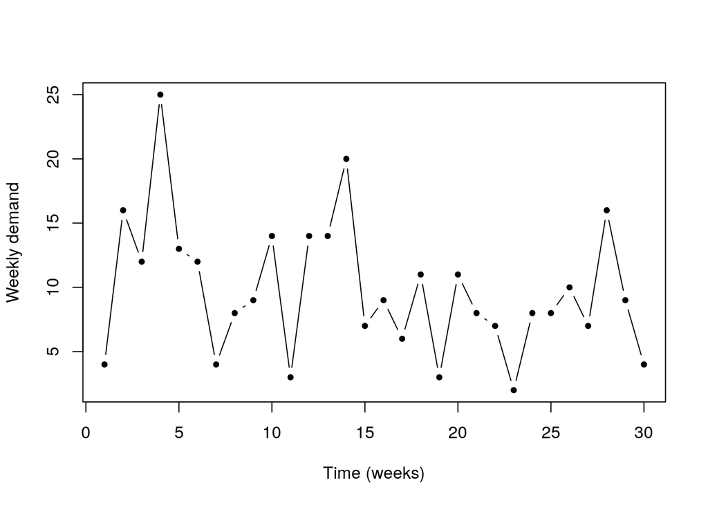

```r
weekly_demand <- c(
  4, 16, 12, 25, 13, 12, 4,  8, 9, 14,
  3, 14, 14, 20,  7,  9, 6, 11, 3, 11,
  8,  7,  2,  8,  8, 10, 7, 16, 9,  4
)
demand_ts <- ts(weekly_demand)
plot.ts(demand_ts, type = 'b', pch = 20,
        xlab = "Time (weeks)",
        ylab = "Weekly demand")
```

```r
passagiers <- ts(start = c(1949, 1),
                 end = c(1960, 12),
                 frequency = 12,
                 data = passagiers2$AirPassengers)
passagiers
```

```
##      Jan Feb Mar Apr May Jun Jul Aug Sep Oct Nov Dec
## 1949 112 118 132 129 121 135 148 148 136 119 104 118
## 1950 115 126 141 135 125 149 170 170 158 133 114 140
## 1951 145 150 178 163 172 178 199 199 184 162 146 166
## 1952 171 180 193 181 183 218 230 242 209 191 172 194
## 1953 196 196 236 235 229 243 264 272 237 211 180 201
## 1954 204 188 235 227 234 264 302 293 259 229 203 229
## 1955 242 233 267 269 270 315 364 347 312 274 237 278
## 1956 284 277 317 313 318 374 413 405 355 306 271 306
## 1957 315 301 356 348 355 422 465 467 404 347 305 336
## 1958 340 318 362 348 363 435 491 505 404 359 310 337
## 1959 360 342 406 396 420 472 548 559 463 407 362 405
## 1960 417 391 419 461 472 535 622 606 508 461 390 432
```

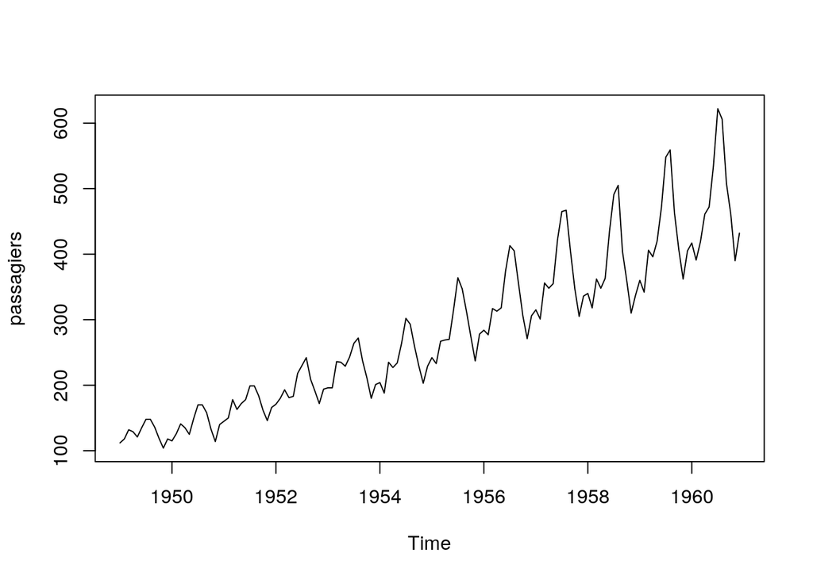

```r
plot.ts(passagiers)
```

Lineaire regressie (Weekly demand hier eens bijgezet omdat er daar gebruik gemaakt wordt van time OF 1:length)

```r
lm(weekly_demand ~ time(weekly_demand))
```

```
##
## Call:
## lm(formula = weekly_demand ~ time(weekly_demand))
##
## Coefficients:
##         (Intercept)  time(weekly_demand)
##             12.6138              -0.1815
```

```r
week <- 1:length(weekly_demand)
lm(weekly_demand ~ week)
```

```
##
## Call:
## lm(formula = weekly_demand ~ week)
##
## Coefficients:
## (Intercept)         week
##     12.6138      -0.1815
```

```r
lm(passagiers ~ time(passagiers))
```

```
##
## Call:
## lm(formula = passagiers ~ time(passagiers))
##
## Coefficients:
##      (Intercept)  time(passagiers)
##        -62055.91             31.89
```

Exponential Moving Average (alpha dicht bij 0 => minder snel vergeten, alpha dicht 1 => snel vergeten) Dit zorgt voor dezelfde voorspelling van 1 punt (meestal niet handig dus)

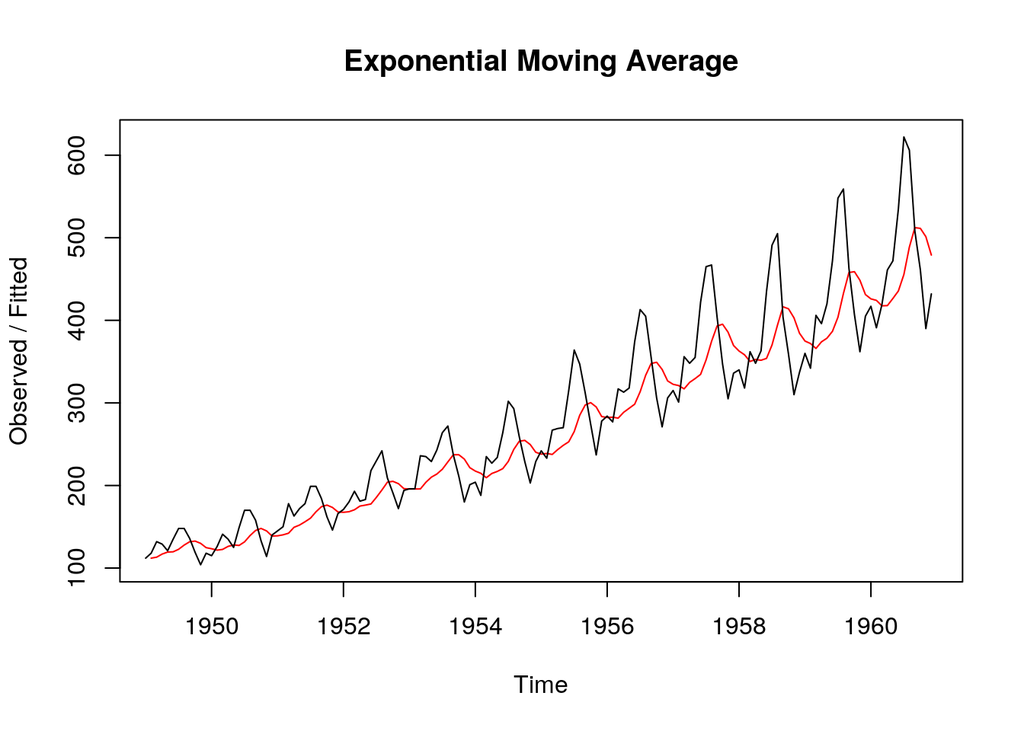

```r
pass_ema1 <- HoltWinters(passagiers, alpha = 0.2, beta = FALSE, gamma = FALSE)
plot(pass_ema1, main = "Exponential Moving Average")
```

```r
pass_ema1_fc <- forecast(pass_ema1, h=10)
pass_ema1_fc
```

```
##          Point Forecast    Lo 80    Hi 80    Lo 95    Hi 95
## Jan 1961       469.6301 410.2691 528.9911 378.8453 560.4149
## Feb 1961       469.6301 409.0936 530.1666 377.0474 562.2127
## Mar 1961       469.6301 407.9404 531.3198 375.2838 563.9764
## Apr 1961       469.6301 406.8084 532.4518 373.5525 565.7077
## May 1961       469.6301 405.6964 533.5638 371.8519 567.4083
## Jun 1961       469.6301 404.6034 534.6568 370.1804 569.0798
## Jul 1961       469.6301 403.5285 535.7317 368.5365 570.7237
## Aug 1961       469.6301 402.4708 536.7894 366.9189 572.3413
## Sep 1961       469.6301 401.4295 537.8306 365.3263 573.9338
## Oct 1961       469.6301 400.4039 538.8563 363.7578 575.5024
```

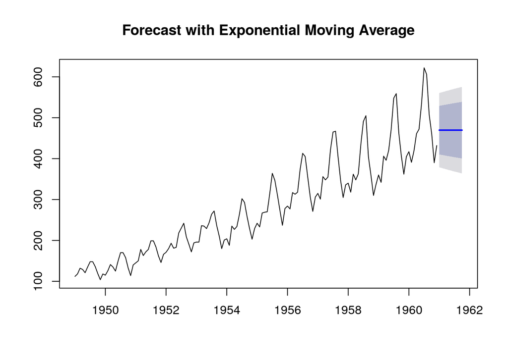

```r
plot(pass_ema1_fc, main = "Forecast with Exponential Moving Average")
```

Double Exponential Moving Average (Voor data met een lange trend, dalend of stijgend) Dit zorgt voor voorspellingen met een stijgende/dalende aard

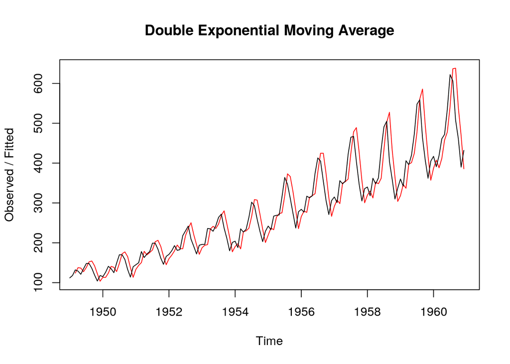

```r
pass_ema2 <- HoltWinters(passagiers, alpha = 0.8, beta = 0.2, gamma = FALSE)
plot(pass_ema2, main = "Double Exponential Moving Average")
```

```r
pass_ema2_fc <- forecast(pass_ema2, h = 10)
pass_ema2_fc
```

```
##          Point Forecast     Lo 80    Hi 80      Lo 95    Hi 95
## Jan 1961       410.1062 359.35958 460.8529 332.495924 487.7165
## Feb 1961       397.4508 327.10490 467.7967 289.866022 505.0356
## Mar 1961       384.7954 294.35809 475.2327 246.483470 523.1073
## Apr 1961       372.1400 260.79300 483.4870 201.849462 542.4305
## May 1961       359.4846 226.29999 492.6692 155.796327 563.1728
## Jun 1961       346.8292 190.84613 502.8122 108.273710 585.3846
## Jul 1961       334.1737 154.43028 513.9172  59.279835 609.0676
## Aug 1961       321.5183 117.06536 525.9713   8.834505 634.2021
## Sep 1961       308.8629  78.77063 538.9552 -43.032861 660.7587
## Oct 1961       296.2075  39.56788 552.8471 -96.288928 688.7039
```

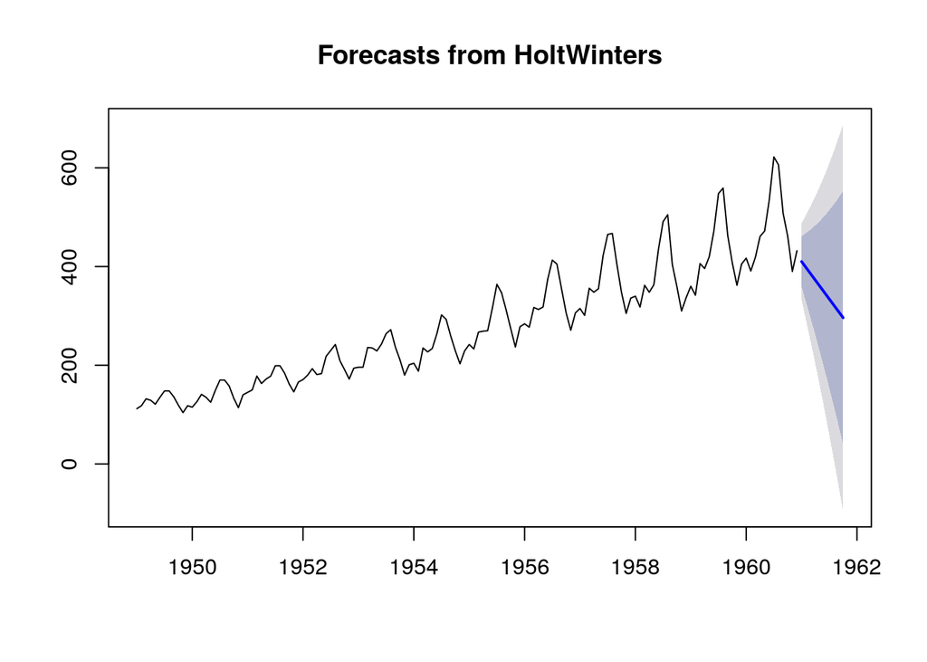

```r
plot(pass_ema2_fc)
```

Triple Exponential Moving Average (voor data met een algemene trend maar met een terugkerend patroon/schommeling)

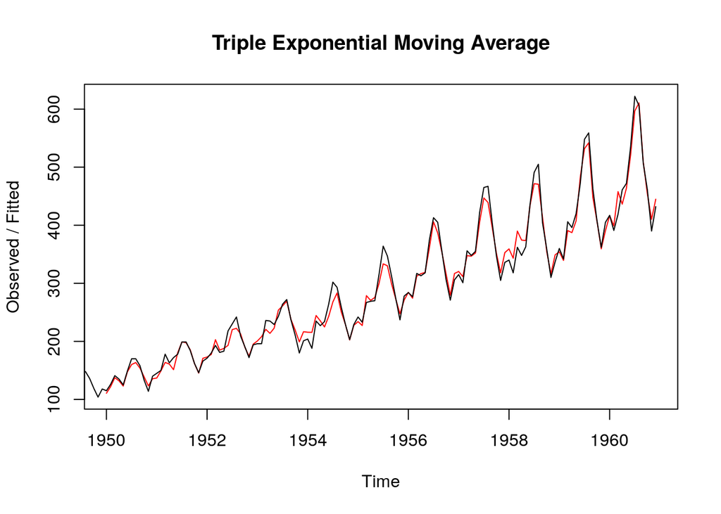

```r
pass_ema3 <- HoltWinters(passagiers)
plot(pass_ema3, main = "Triple Exponential Moving Average")
```

```r
pass_ema3_fc <- forecast(pass_ema3, h = 24)
pass_ema3_fc
```

```
##          Point Forecast    Lo 80    Hi 80    Lo 95    Hi 95
## Jan 1961       453.4977 437.0972 469.8983 428.4153 478.5802
## Feb 1961       429.3906 412.4590 446.3221 403.4960 455.2851
## Mar 1961       467.0361 449.5553 484.5169 440.3015 493.7706
## Apr 1961       503.2574 485.2097 521.3051 475.6558 530.8590
## May 1961       512.3395 493.7078 530.9713 483.8447 540.8343
## Jun 1961       571.8880 552.6556 591.1204 542.4746 601.3014
## Jul 1961       652.6095 632.7605 672.4586 622.2530 682.9661
## Aug 1961       637.4623 616.9809 657.9436 606.1387 668.7858
## Sep 1961       539.7548 518.6260 560.8835 507.4412 572.0684
## Oct 1961       490.7250 468.9342 512.5158 457.3988 524.0511
## Nov 1961       424.4593 401.9922 446.9264 390.0988 458.8197
## Dec 1961       469.5315 446.3742 492.6888 434.1155 504.9475
## Jan 1962       491.0292 461.6463 520.4121 446.0920 535.9665
## Feb 1962       466.9221 436.9542 496.8900 421.0901 512.7540
## Mar 1962       504.5676 473.9985 535.1367 457.8162 551.3190
## Apr 1962       540.7889 509.6027 571.9751 493.0938 588.4841
## May 1962       549.8710 518.0522 581.6899 501.2083 598.5338
## Jun 1962       609.4195 576.9526 641.8863 559.7657 659.0732
## Jul 1962       690.1411 657.0112 723.2709 639.4734 740.8087
## Aug 1962       674.9938 641.1863 708.8012 623.2897 726.6978
## Sep 1962       577.2863 542.7868 611.7858 524.5239 630.0487
## Oct 1962       528.2565 493.0509 563.4621 474.4141 582.0989
## Nov 1962       461.9908 426.0652 497.9164 407.0473 516.9343
## Dec 1962       507.0630 470.4039 543.7222 450.9977 563.1283
```

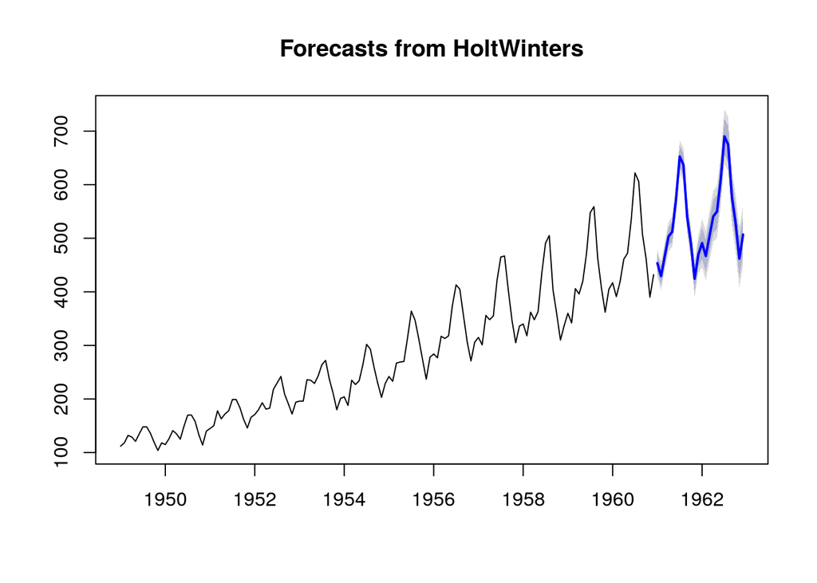

```r
plot(pass_ema3_fc)
```